# MODELO VOTKA VOLTERRA

## ¿QUE ES EL MODELO?

El modelo VOTKA VOLTERRA es un modelo de ecuaciones diferenciales que define el cómo funciona la presa y el depredador Las ecuaciones de Lotka-Volterra son un par de ecuaciones diferenciales de primer orden, no lineales, que se utilizan para describir la dinámica de sistemas biológicos en los que interactúan dos especies: una depredadora y otra presa. Estas ecuaciones capturan la interacción entre ambas poblaciones, modelando su crecimiento y declive en función de las tasas de depredación y reproducción.

```python
import matplotlib.pyplot as plt
from random import *
from numpy import *
import sys
```

```python
a = 0.7; b = 0.3; c = 0.3;  e = 0.9 #ejercicio 1
dt = 0.001; max_time = 100

# initial time and populations
t = 0; x = 1.0; y = 1.0
```

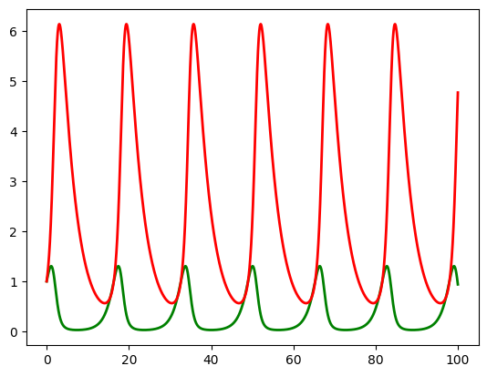

```python
# empty lists in which to store time and populations
t_list = []; x_list = []; y_list = []

# initialize lists
t_list.append(t); x_list.append(x); y_list.append(y)

while t < max_time:
    # calc new values for t, x, y
    t = t + dt
    x = x + (a*x - b*x*y)*dt
    y = y + (-c*y + e*x*y)*dt

    # store new values in lists
    t_list.append(t)
    x_list.append(x)
    y_list.append(y)

# Plot the results
p = plt.plot(t_list, x_list, 'g', t_list, y_list, 'r', linewidth = 2)
```

Como se observa, cuando incrementan las presas incrementa un poco los depredadores, estos depredadores crecen significativamente, y observamos como necesitamos de más variables para que sea constante, y una mejor predicción del mundo real, dado que no es posible que mientras existan menos presas, aumente el número de depredadores

```python
a = 0.4; b = 0.3; c = 0.3;  e = 0.2 #ejercicio 2
dt = 0.001; max_time = 100

# initial time and populations
t = 0; x = 1.0; y = 1.0
```

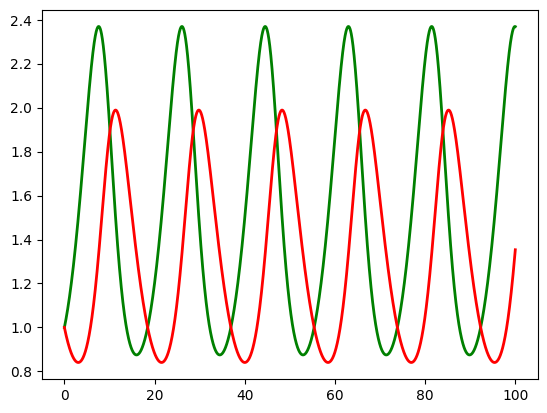

```python
# empty lists in which to store time and populations
t_list = []; x_list = []; y_list = []

# initialize lists
t_list.append(t); x_list.append(x); y_list.append(y)

while t < max_time:
    # calc new values for t, x, y
    t = t + dt
    x = x + (a*x - b*x*y)*dt
    y = y + (-c*y + e*x*y)*dt

    # store new values in lists
    t_list.append(t)
    x_list.append(x)
    y_list.append(y)

# Plot the results
p = plt.plot(t_list, x_list, 'g', t_list, y_list, 'r', linewidth = 2)
```

ahora vemos las presas son más, y posteriormente llegan los depredadores para poder igualar por así decirlo, cuando decaen las presas decaen los depredadores, y así llegan al final, el modelo tiene picos de altitud en las presas, porque tiene un mayor índice de crecimiento que los depredadores ahora bien, justo cuando chocan los índices, estos incrementan, hasta llegar a su punto máximo y de ahí descienden

```python
a = 0.8; b = 0.4; c = 0.2;  e = 0.7 #ejercicio 3
dt = 0.001; max_time = 100

# initial time and populations
t = 0; x = 0.0; y = 1.0
```

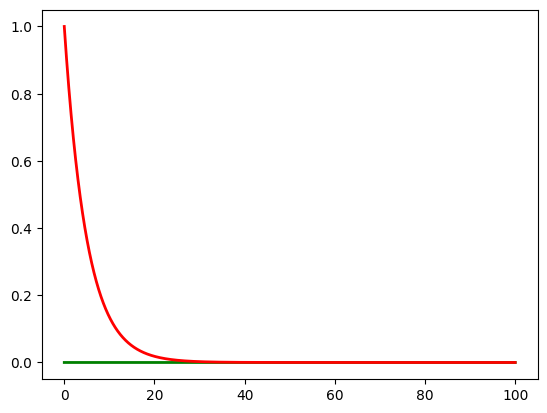

```python
# empty lists in which to store time and populations
t_list = []; x_list = []; y_list = []

# initialize lists
t_list.append(t); x_list.append(x); y_list.append(y)

while t < max_time:
    # calc new values for t, x, y
    t = t + dt
    x = x + (a*x - b*x*y)*dt
    y = y + (-c*y + e*x*y)*dt

    # store new values in lists
    t_list.append(t)
    x_list.append(x)
    y_list.append(y)

# Plot the results
p = plt.plot(t_list, x_list, 'g', t_list, y_list, 'r', linewidth = 2)
```

ahora vemos una variación un poco extraña, si las presas son cero, nuestros depredadores van a decaer, hasta también llegar a ser cero, este ya es algo verdadero, si los depredadores existen y necesitan alimento por así decirlo, y no lo consiguen, estos llegan a morir, hasta reducir su población a cero lo vemos como algo fácil, pero las ecuaciones mencionadas anteriormente sugieren esto, y también sugieren en cuanto tiempo, por ejemplo, la población llega a cero, en digamos 20 unidades de tiempo

```python
a = 0.8; b = 0.4; c = 0.2;  e = 0.7 #ejercicio 3
dt = 0.001; max_time = 100

# initial time and populations
t = 0; x = 1.0; y = 0.0
```

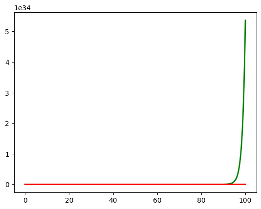

```python
# empty lists in which to store time and populations
t_list = []; x_list = []; y_list = []

# initialize lists
t_list.append(t); x_list.append(x); y_list.append(y)

while t < max_time:
    # calc new values for t, x, y
    t = t + dt
    x = x + (a*x - b*x*y)*dt
    y = y + (-c*y + e*x*y)*dt

    # store new values in lists
    t_list.append(t)
    x_list.append(x)
    y_list.append(y)

# Plot the results
p = plt.plot(t_list, x_list, 'g', t_list, y_list, 'r', linewidth = 2)
```

ahora si es lo contrario, vemos como la población de presas, se va a tener un crecimiento exponencial, dado que no hay un depredador que las ayude a tener un equilibrio

```python
a = 0.3; b = 0.4; c = 0.2;  e = 0.5 #ejercicio 3
dt = 0.001; max_time = 100

# initial time and populations
t = 0; x = 1.0; y = 1.0
```

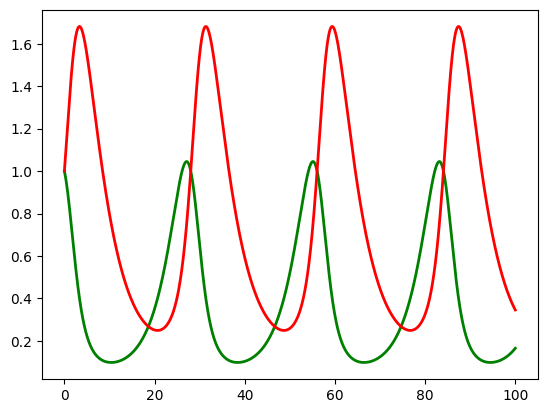

```python
# empty lists in which to store time and populations
t_list = []; x_list = []; y_list = []

# initialize lists
t_list.append(t); x_list.append(x); y_list.append(y)

while t < max_time:
    # calc new values for t, x, y
    t = t + dt
    x = x + (a*x - b*x*y)*dt
    y = y + (-c*y + e*x*y)*dt

    # store new values in lists
    t_list.append(t)
    x_list.append(x)
    y_list.append(y)

# Plot the results
p = plt.plot(t_list, x_list, 'g', t_list, y_list, 'r', linewidth = 2)
```

observamos como mientras los depredadores suben, las presas llegan a bajar, vemos que también mientras las presas suben los depredadores bajan esto ya se acerca demasiado a la realidad, vemos como pueden incluso llegar a rozar el cero, y los depredadores casi nunca llegarán, siempre tendrán más esperanza que las presas incluso cuando empiezan, las presas directamente van hacia abajo, esto se parece demasiado a la realidad, y como las poblaciones de distintos animales se pueden graficar de esa manera

```python
a = 0.2; b = 0.2; c = 0.2;  e = 0.2 #ejercicio 3
dt = 0.001; max_time = 100

# initial time and populations
t = 0; x = 1.0; y = 1.0
```

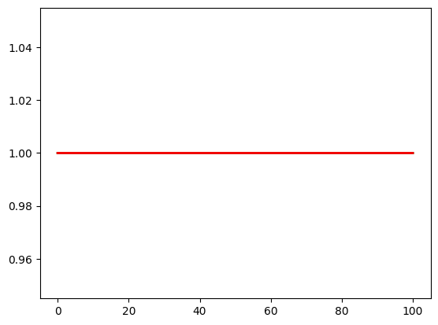

```python
# empty lists in which to store time and populations
t_list = []; x_list = []; y_list = []

# initialize lists
t_list.append(t); x_list.append(x); y_list.append(y)

while t < max_time:
    # calc new values for t, x, y
    t = t + dt
    x = x + (a*x - b*x*y)*dt
    y = y + (-c*y + e*x*y)*dt

    # store new values in lists
    t_list.append(t)
    x_list.append(x)
    y_list.append(y)

# Plot the results
p = plt.plot(t_list, x_list, 'g', t_list, y_list, 'r', linewidth = 2)
```

ahora vemos como los depredadores y presas están en equilibrio constante, siempre tendrá uno, ya sea que se coma al otro, o no pueda sobrevivir, pero siempre estarán en un equilibrio constante